# Math 421 - Midterm

## Instruction

The midterm has two components: the Rmarkdown notebook (html) and the presentation. We will do the presentation in class. Post both the notebook and the presentation on your Github page.

**The notebook:** The notebook should be created using `rmarkdown` (like other assignments). The notebook should have a title. It should have a table of content (TOC form) or in a tab form. The Rmd files of Tab and Toc form are available on the class webpage.

**The Presentation:** Present your results in 5-10 minutes. To make the presentation using Rmarkdown, do the follows:

```
- In Rstudio -> File -> New File -> R markdown

- In the left panel, click to Presentation -> Click OK

- Now you have an Rmarkdown that can be knitted to be a html presentation
```

- You can also use Rmd samples of the class slides that are available on the class webpage.
- You do not need to rerun all the codes for the presentation. For example, to show the model comparison, you just need to show the image of the model comparison instead of running all the models again.
- To inset an image in a slide, use `![](image.png)`
- To scale images, you can follow these below instructions.
  - https://bookdown.org/yihui/rmarkdown-cookbook/figure-size.html
  - http://zevross.com/blog/2017/06/19/tips-and-tricks-for-working-with-images-and-figures-in-r-markdown-documents/
- To turn off message and warning of a code cell, use: `{r, message=FALSE, warning=FALSE}` for the cell.

**What to present**:

- Present Part 2 - Visualization
- Present Question Question 4, 5 and 6 in Part 3.
- Present any errors/challenges you run into and how you fix/overcome them.

**Data:**

The data for the mid-term project is the Rhode Island Department of Health Hospital Discharge Data. Each row of the data presents a patient.

Link: https://drive.google.com/open?id=15QNBf6YYKocK2nNIfpKDer58kQnCPNZJ

## I. Data Wranggling

1. Download the data file `hdd0318cy.sas7bdat`.
2. Use `read_sas` in library `haven` to read the data.

```r
library(haven)
setwd("C:\\Users\\student\\Desktop")
df <- read_sas("hdd0318cy.sas7bdat")
setwd("C:/Users/student/Desktop/R Math421/rwalsh11.github.io/")
```

3. Filter the data to have only patients of the year 2018 (`yod=2018`)

```r
library(tidyverse)
df1 <- df %>% filter(yod=='18')
```

4. Select to work with only following variables:

```r
                      "yod", "payfix","pay_ub92","age",
                      "sex","raceethn","provider","moa",
                      "yoa","mod","admtype", "asource" ,
                      "preopday" ,"los", "service" , "icu","ccu",
                      "dispub92", "payer"  ,"drg","trandb",
                      "randbg","randbs","orr", "anes","seq",
                      "lab","dtest", "ther","blood","phar",
                      "other","patcon","bwght","total","tot" ,
                      "ecodub92","b_wt","pt_state","diag_adm","ancilar" ,
                      "campus","er_fee","er_chrg","er_mode","obs_chrg",
                      "obs_hour","psycchrg","nicu_day"
```

*Notice*: You may want to save the current data to your computer for easy access later. To save the data file use `write_csv(df, 'midterm.csv')`, for example.

```r
library(dplyr)
df1 <- df1 %>% select("yod", "payfix","pay_ub92","age",
                      "sex","raceethn","provider","moa",
                      "yoa","mod","admtype", "asource" ,
                      "preopday" ,"los", "service" , "icu","ccu",
                      "dispub92", "payer"  ,"drg","trandb",
                      "randbg","randbs","orr", "anes","seq",
                      "lab","dtest", "ther","blood","phar",
                      "other","patcon","bwght","total","tot" ,
                      "ecodub92","b_wt","pt_state","diag_adm","ancilar" ,
                      "campus","er_fee","er_chrg","er_mode","obs_chrg",
                      "obs_hour","psycchrg","nicu_day")
library(tidyverse)
write_csv(df1, 'midterm.csv')
```

5. What are variables that have missing values?

```r
library(tidyverse)
df1 <- read_csv("midterm.csv")
colSums(is.na(df1))
```

```
##      yod   payfix pay_ub92      age      sex raceethn provider      moa
##        0   131478        0        0        0     3950        0        0
##      yoa      mod  admtype  asource preopday      los  service      icu
##        0        0        1        6    60486        0        0        0
##      ccu dispub92    payer      drg   trandb   randbg   randbs      orr
##        0        0        0        0        0        0        0        0
##     anes      seq      lab    dtest     ther    blood     phar    other
##        0        0        0        0        0        0        0        0
##   patcon    bwght    total      tot ecodub92     b_wt pt_state diag_adm
##        0   131478        0        0   104339        0        3       50
##  ancilar   campus   er_fee  er_chrg  er_mode obs_chrg obs_hour psycchrg
##        0        0        0        0    12158        0    77343        0
## nicu_day
##   124090
```

6. Remove all variables with missing values.

```r
df1 %>% select(-nicu_day,-er_mode,-obs_hour,-ecodub92,-payfix,-diag_adm,-bwght,-preopday)
```

```
## # A tibble: 131,478 × 41
##      yod pay_ub92   age   sex raceethn provi…¹   moa   yoa   mod admtype asource
##    <dbl>    <dbl> <dbl> <dbl>    <dbl>   <dbl> <dbl> <dbl> <dbl>   <dbl> <chr>
##  1    18        9     0     1        1    7214     1    18     1       4 S
##  2    18        2    76     2        1    7214     1    18     1       3 1
##  3    18        6    50     2        1    7214    12    17     1       2 1
##  4    18        4     0     1        7    7214     1    18     1       4 S
##  5    18       13     0     1        1    7214    12    17     1       4 S
##  6    18        4     0     2        9    7214    12    17     1       4 T
##  7    18        4     0     2        1    7214     1    18     1       4 S
##  8    18       13     0     2        1    7214     1    18     1       4 S
##  9    18        1    70     2        1    7214     1    18     1       2 1
## 10    18        9    25     2        1    7214    12    17     1       2 1
## # … with 131,468 more rows, 30 more variables: los <dbl>, service <chr>,
## #   icu <chr>, ccu <chr>, dispub92 <chr>, payer <chr>, drg <dbl>, trandb <chr>,
## #   randbg <chr>, randbs <chr>, orr <chr>, anes <chr>, seq <chr>, lab <chr>,
## #   dtest <chr>, ther <chr>, blood <chr>, phar <chr>, other <chr>,
## #   patcon <chr>, total <chr>, tot <dbl>, b_wt <chr>, pt_state <chr>,
## #   ancilar <chr>, campus <dbl>, er_fee <chr>, er_chrg <chr>, obs_chrg <chr>,
## #   psycchrg <chr>, and abbreviated variable name ¹provider
```

data wrangling to better view providers

```r
df1$provider1 <- case_when(df1$provider == 7201 ~ "Newport", df1$provider == 7202 ~ "St. Joseph Health Services of RI",df1$provider == 7203 ~ "Memorial",df1$provider == 7204 ~ "Miriam",df1$provider == 7205 ~ "Rhode Island Hospital",df1$provider == 7206 ~ "Roger Williams",df1$provider == 7209 ~ "South County",df1$provider == 7210 ~ "Kent County",df1$provider == 7211 ~ "Westerly",df1$provider == 7212 ~ "Rehab of RI",df1$provider == 7213 ~ "Landmark Medical Center",df1$provider == 7214 ~ "Women and Infants",df1$provider == 7215 ~ "Bradley",df1$provider == 7216 ~ "Butler",)
```

7. Refer to the data description in the file `HDD2015-18cy6-20-19.docx`, which variable recording the month of admission?, which variable recording the month of discharge?

```r
table(df1$moa)
```

```
##
##     1     2     3     4     5     6     7     8     9    10    11    12
## 11309 10259 11073 11174 11404 10690 10962 11199 10666 11408 10636 10698
```

```r
table(df1$mod)
```

```
##
##     1     2     3     4     5     6     7     8     9    10    11    12
## 11199 10248 11164 11049 11419 10892 10725 11307 10622 11384 10669 10800
```

```r
#neither of these work(having major trouble viewing data)
```

8. Which month admitted the most number of patients? Which month admitted the most number of male patients?

```r
table(df1$moa)
```

```
##
##     1     2     3     4     5     6     7     8     9    10    11    12
## 11309 10259 11073 11174 11404 10690 10962 11199 10666 11408 10636 10698
```

```r
q8 <-  df1 %>%  filter(sex == 1)
table(q8$moa)
```

```
##
##    1    2    3    4    5    6    7    8    9   10   11   12
## 4970 4546 4978 4989 5066 4810 4910 5028 4683 5164 4800 4855
```

The males make up for about half of all admissions, month 10, October appears to be the month with the most admitted patients both with respect to everyone and with respect to just men.

9. Which month has the most number of teenage female patients?

```r
q9 <- df1 %>% filter(sex == 2, age < 20)
table(q9$moa) #month 5 is best
```

```
##
##   1   2   3   4   5   6   7   8   9  10  11  12
## 861 726 843 792 868 716 735 773 814 779 792 828
```

10. Which provider has the most number of female patients in October?

```r
table(df1$provider)
```

```
##
##  7201  7202  7204  7205  7206  7209  7210  7211  7213  7214  7215  7216
##  5556  5293 19246 36693  6864  6681 15437  2698  6303 19161  1101  6445
```

```r
q10 <- df1 %>% filter(sex == 2,moa ==10)
table(q10$provider)
```

```
##
## 7201 7202 7204 7205 7206 7209 7210 7211 7213 7214 7215 7216
##  294  212  872 1517  333  351  699  122  317 1224   46  256
```

provider number 7205(rhode island hopsital) has the most ammount of female patients in october.

11. Are female patients older than male patients, on average?

```r
d1 <- df1 %>% group_by(sex == 1) %>% summarise(mean = mean(age))
d2 <- df1 %>% group_by(sex == 2) %>% summarise(mean = mean(age))
d1
```

```
## # A tibble: 2 × 2
##   `sex == 1`  mean
##   <lgl>      <dbl>
## 1 FALSE       50.9
## 2 TRUE        51.5
```

```r
d2
```

```
## # A tibble: 2 × 2
##   `sex == 2`  mean
##   <lgl>      <dbl>
## 1 FALSE       51.5
## 2 TRUE        50.9
```

12. Calculate the average age of patients by months. Which month has the oldest patients on average age?

```r
d3 <- df1 %>% group_by(moa) %>% summarise(mean = mean(age))
d3
```

```
## # A tibble: 12 × 2
##      moa  mean
##    <dbl> <dbl>
##  1     1  51.8
##  2     2  51.2
##  3     3  51.1
##  4     4  51.4
##  5     5  50.6
##  6     6  51.5
##  7     7  51.3
##  8     8  50.9
##  9     9  50.6
## 10    10  50.8
## 11    11  51.0
## 12    12  51.5
```

13. What is the name of the provider that has the highest total charge?

```r
q13 <- df1 %>% group_by(provider) %>% summarise(max =max(tot))
q13
```

```
## # A tibble: 12 × 2
##    provider     max
##       <dbl>   <dbl>
##  1     7201  365044
##  2     7202 1477944
##  3     7204 1040507
##  4     7205 2991708
##  5     7206  802758
##  6     7209  282223
##  7     7210 1375171
##  8     7211  331604
##  9     7213  608086
## 10     7214 3402056
## 11     7215 2418518
## 12     7216 1532326
```

```r
max(q13) #Woman and infants
```

```
## [1] 3402056
```

14. What is the name of the provider that has the least total charge for teenage male on average?

```r
df1$total <- as.numeric(df1$total)
df1 %>% filter(sex == 1) %>%  group_by(provider1) %>% summarise(mean = mean(total))
```

```
## # A tibble: 12 × 2
##    provider1                          mean
##    <chr>                             <dbl>
##  1 Bradley                          86740.
##  2 Butler                           16606.
##  3 Kent County                      28307.
##  4 Landmark Medical Center          39733.
##  5 Miriam                           36296.
##  6 Newport                          23197.
##  7 Rhode Island Hospital            51022.
##  8 Roger Williams                   31549.
##  9 South County                     26509.
## 10 St. Joseph Health Services of RI 36122.
## 11 Westerly                         25629.
## 12 Women and Infants                25295.
```

15. Create a season (Spring, Summer, Fall, Winter) variable. Calculate the length of stays by season. Which season has the longest length of stays on average?

```r
df1$season <- case_when(df1$moa %in% c("3","4","5") ~ 'spring',
                       df1$moa %in% c("6","7","8") ~ 'summer', df1$moa %in% c("9","10","11") ~ 'fall', df1$moa %in% c("12","1","2") ~ 'winter')

df1 %>% group_by(season) %>% summarise(mean = mean(los))
```

```
## # A tibble: 4 × 2
##   season  mean
##   <chr>  <dbl>
## 1 fall    4.96
## 2 spring  4.84
## 3 summer  4.96
## 4 winter  4.93
```

16. On average, how much a 20 year-old male get charged for staying 1 day in the Fall season?

```r
q16 <- df1 %>%  filter(sex == 1, los == 1, age == 20, season == "fall")
q16 %>% summarise(mean = mean(tot))
```

```
## # A tibble: 1 × 1
##    mean
##   <dbl>
## 1 16511
```

17. Write a paragraph to summarize the section and give your comments on the results. You could do some other calculations to support your points.

```r
#this section was very useful in terms of us cleaning and begining to visualize the data set we are working with. After removing variables in which were missing values, we were still able to see ways in which this data can and will be used. another thing to note is as I did the required stratification I discovered interesting things with respect to comparative stratification. For example when investigating how much on average a 20 year old male spends on a one night stay which we found to be $16511.00, however what is interesting is that with respect to a female in the same position it is $9676.182. These kinds of differences are significant and should be investigated further.
```

## II. Data Visualization

Continue with the data from part I.

1. Provides at least 10 meaningful plots. Comments on the plots. All plots should have title, caption, appropriate labels on x and y-axis

```r
df1$sex1 <- case_when(df1$sex == 1 ~ 'male',df1$sex == 2 ~ 'female', df1$sex == 9 ~'Other')
```

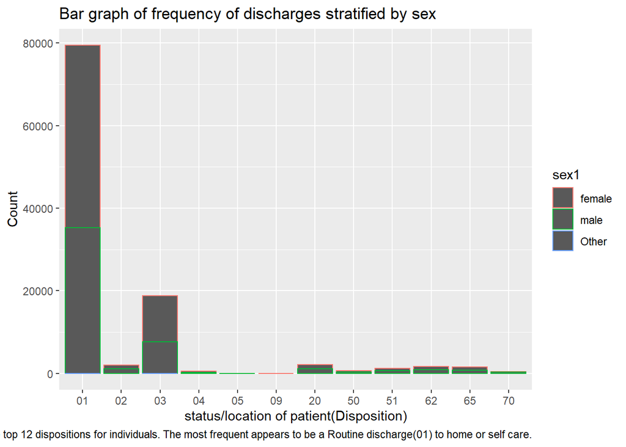

```r
m8 <- df1 %>% filter(dispub92 %in% c("01","02","03","04","05","09","20","50","51","62","65","70")) %>% ggplot(aes(x = dispub92, color = sex1))+
  geom_bar()+
  labs(x = "status/location of patient(Disposition)",y = "Count",title = 'Bar graph of frequency of discharges stratified by sex', caption = "The top 12 dispositions for individuals. The most frequent appears to be a Routine discharge(01) to home or self care.")
ggsave(filename = 'Dispotion.png', plot = m8)
m8
```

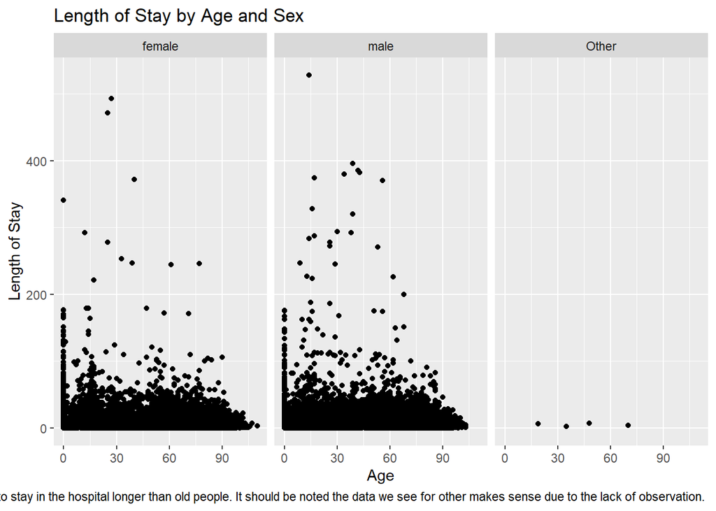

```r
library(ggplot2)
m7 <- df1 %>% ggplot() + geom_point(mapping=aes(x=age, y=los)) + facet_wrap(~sex1) +
  labs(x='Age',
       y = 'Length of Stay',
       title = 'Length of Stay by Age and Sex',
       caption = 'On average younger people seem to stay in the hospital longer than old people. It should be noted the data we see for other makes sense due to the lack of observation. ')
m7
```

```r
ggsave(filename = 'AgevLos.png', plot = m7)
```

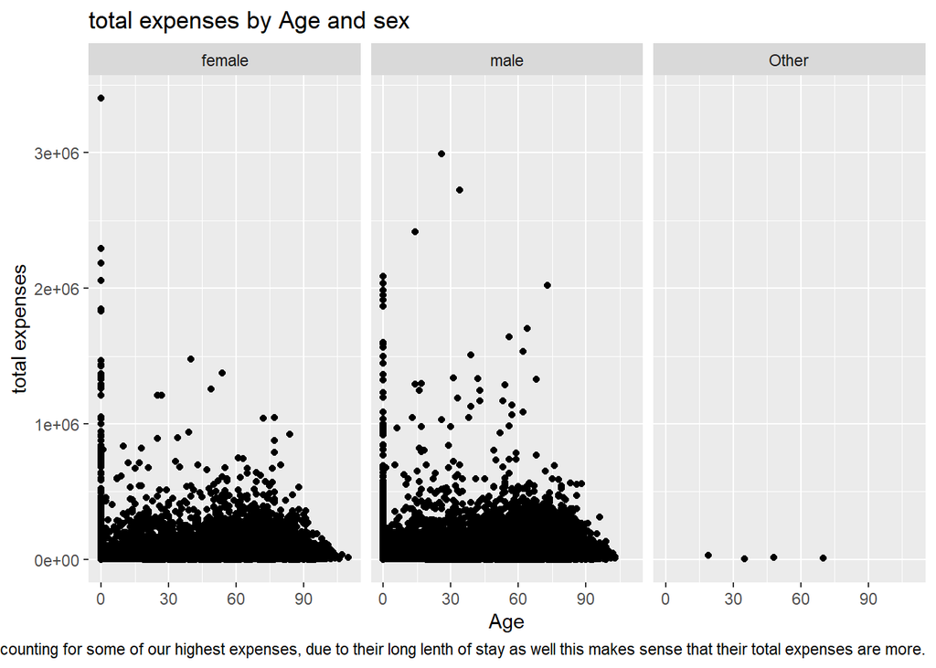

```r
m6 <- df1 %>% ggplot() + geom_point(mapping=aes(x=age, y=tot)) + facet_wrap(~sex1) +
  labs(x='Age',
       y = 'total expenses',
       title = 'total expenses by Age and sex',
       caption = 'Once again we see indiviudals who are young(< 10 years old) accounting for some of our highest expenses, due to their long lenth of stay as well this makes sense that their total expenses are more.')
ggsave(filename = 'AgevTot.png', plot = m6)
m6
```